# Deakin Study Programing Exercise

Hannah S. Heinrichs

12/14/2021

# Inspection of single dataset

The example data is actigraphy data of a dyad with one client and their partner. The data was sampled with 1 Hz in 60-second epochs. Participants have different measurement coverage.

The client’s epochs start at 2016-11-22 17:03:00 and end at 2016-11-30 17:52:00. The time series spans 9 days, including 9 ACTIVE periods, 8 REST periods and 8 SLEEP periods. The dataset contains 11570 observations, 11240 complete observations with data in all variables, 05:30:00 hours are not covered (2.85%). 14 periods of at least 1 minute have missing observations in one or more variables.

Investigations of time periods where one or more variables are missing suggest, failure to records stems from taking of the device, e.g. for showering in the morning, forgetting to put the device on again (several hours missing), or technical failures (several minutes missing).

Table 1

| Group | Start Time | End Time | Duration |
| --- | --- | --- | --- |
| Client | 2016-11-22 17:03:00 | 2016-11-22 17:39:00 | 36 mins |
| Client | 2016-11-24 07:57:00 | 2016-11-24 08:05:00 | 8 mins |
| Client | 2016-11-25 06:17:00 | 2016-11-25 06:43:00 | 26 mins |
| Client | 2016-11-26 07:31:00 | 2016-11-26 07:43:00 | 12 mins |
| Client | 2016-11-26 11:59:00 | 2016-11-26 12:23:00 | 24 mins |
| Client | 2016-11-27 09:46:00 | 2016-11-27 10:02:00 | 16 mins |
| Client | 2016-11-28 19:19:00 | 2016-11-28 22:09:00 | 170 mins |
| Client | 2016-11-29 19:56:00 | 2016-11-29 20:07:00 | 11 mins |
| Client | 2016-11-29 22:28:00 | 2016-11-29 22:38:00 | 10 mins |
| Client | 2016-11-30 07:43:00 | 2016-11-30 07:55:00 | 12 mins |
| Partner | 2016-11-22 17:10:00 | 2016-11-22 20:41:00 | 211 mins |
| Partner | 2016-11-23 05:09:00 | 2016-11-23 05:39:00 | 30 mins |
| Partner | 2016-11-24 05:13:00 | 2016-11-24 05:41:00 | 28 mins |
| Partner | 2016-11-25 05:13:00 | 2016-11-25 05:34:00 | 21 mins |
| Partner | 2016-11-27 17:14:00 | 2016-11-27 18:07:00 | 53 mins |
| Partner | 2016-11-28 22:02:00 | 2016-11-28 22:10:00 | 8 mins |
| Partner | 2016-11-30 05:29:00 | 2016-11-30 17:57:00 | 748 mins |

Note:  
Only periods with missing values of > 5 minutes are reported.

## Smoothing

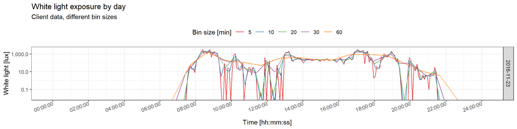

Figure 1. White light exposure, log scaled.

Visual inspection of the time course of white light exposure with different time bins suggests that bin of 20 and even more 30 minutes may capture relevant variation best while smoothing over noisy variation. Smaller bins (e.g. 5 or 10 minutes) heavily depend on occasional extreme values, while larger bins (e.g. 60 minutes) flatten regional changes that may still be of interest. Thus, further analysis is based on 30-minute bins.

## Mean light exposure and activity

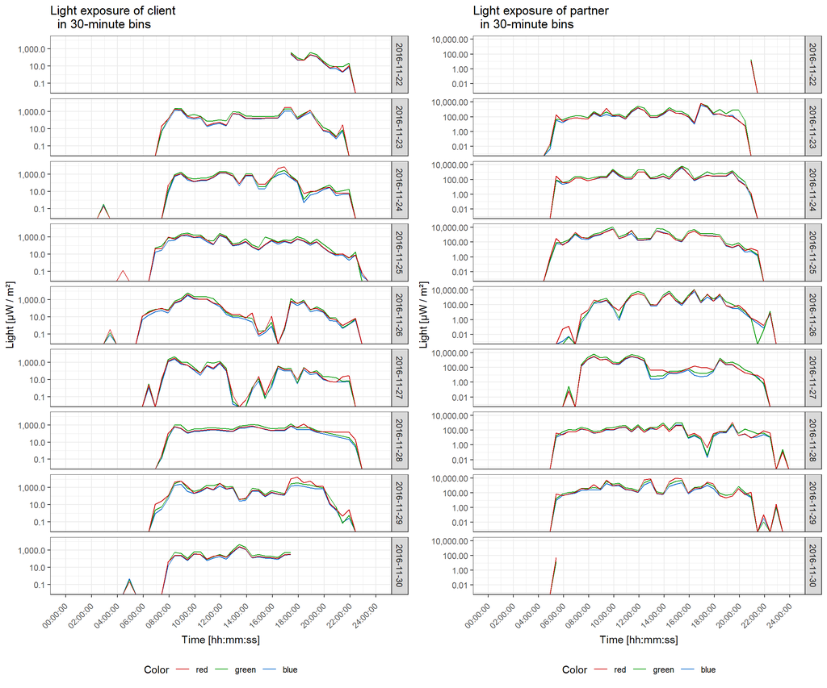

Figure 2

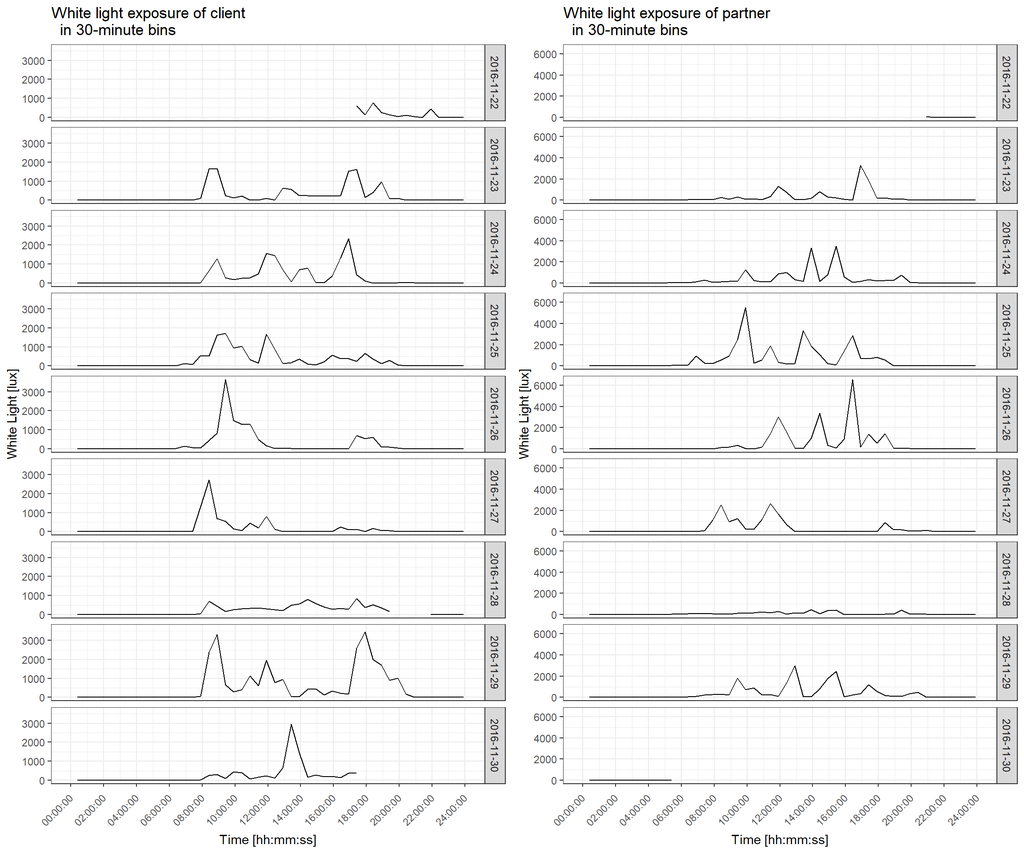

Figure 3

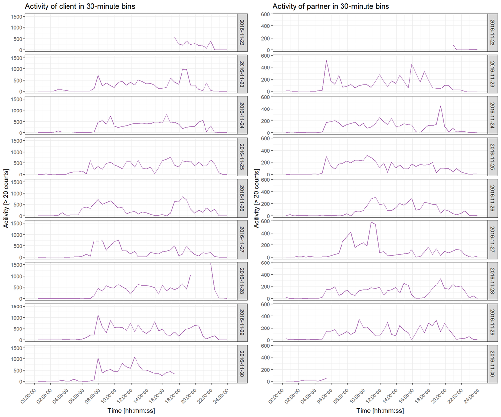

Figure 4

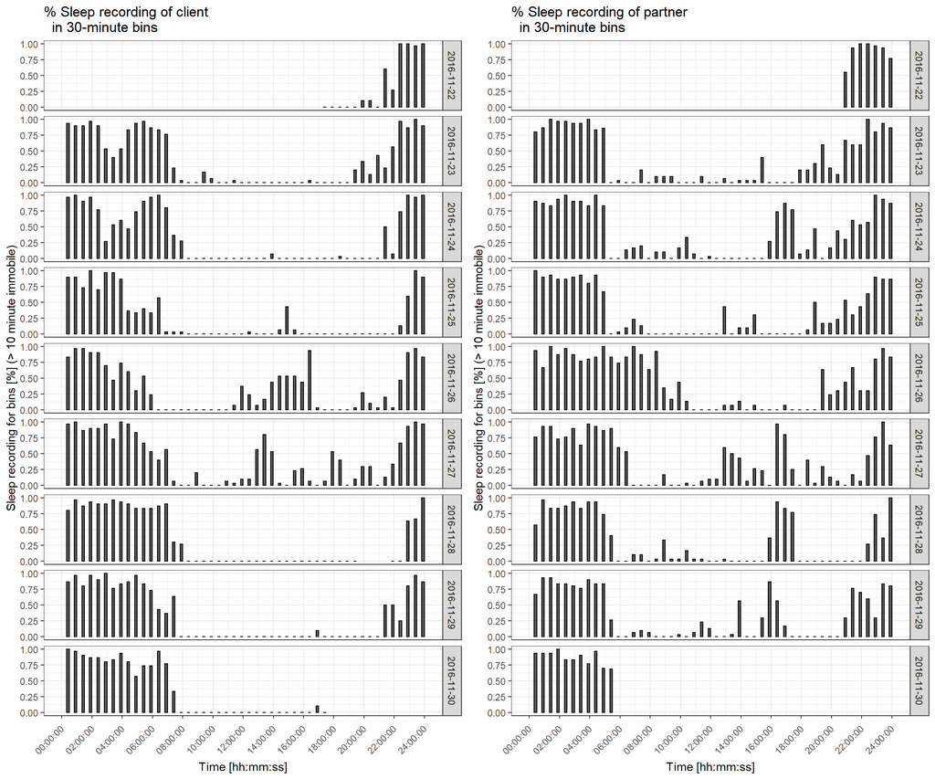

Figure 5

The clients has lower fractions of sleep recording during night time hours and generally less sleep recording than the partner, descriptively confirming sleep disturbance in accordance with the diagnosis. With respect, to light exposure and activity levels, the client and their partner may differ slightly, but not enough to establish presence of a difference by visual inspection of the time series.

## Regularity light exposure and activity

Regularity of light exposure and activity across the time of data collection be examined visually.

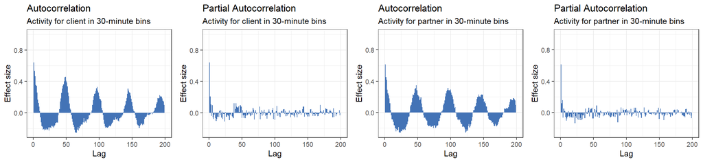

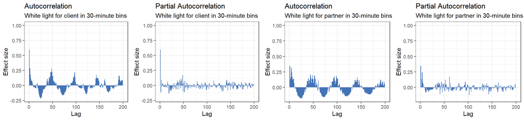

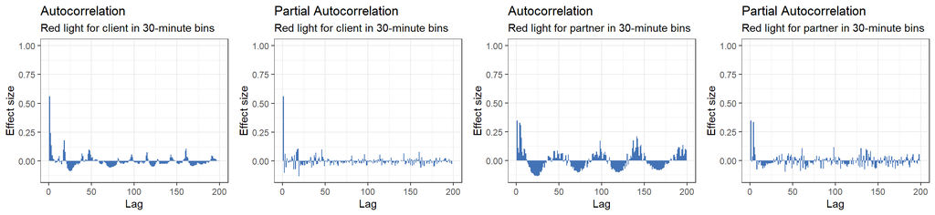

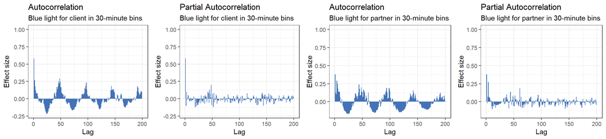

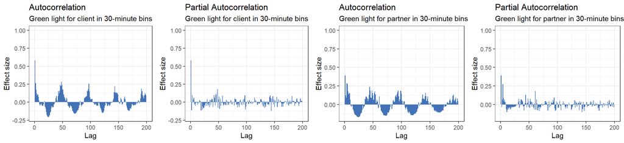

Visually, autocorrelations for activity do not differ between client and partner. Activity, as the only endogenous variable, clearly shows a regular circadian rhythm. For the other exogenous variables, white light, red light, blue light, and green light, autocorrelations are less pronounced for the client compared to the partner. Only autocorrelations of red light reveal disrupted circadian rhythm for the client but not for the partner. Quantitatively, the maximum of autocorrelations in a window between 12 and 36 hours are around 24 hours for both, client and partner, and thus do not suggest any deviation from circadian rhythm (see below). For detailed quantitative evaluation of regularity and periodicity, other statistical means may be employed, such as time frequency analysis.

Table 2

| Target | Group name | Time of maximum AC |
| --- | --- | --- |
| Activity | Client | 24:30:00 |
| Activity | Partner | 24:00:00 |
| Blue light | Client | 24:00:00 |
| Blue light | Partner | 22:00:00 |
| Green light | Client | 24:00:00 |
| Green light | Partner | 22:00:00 |
| Red light | Client | 23:30:00 |
| Red light | Partner | 24:00:00 |
| White light | Client | 24:00:00 |
| White light | Partner | 22:00:00 |

Note:  
AC: Autocorrelation

## Correlation of light exposure and activity

To analyze the relationship between light exposure and activity, cross correlations were computed to examine irregularities in their relationship across time.

Strikingly, there are small deflections of the client’s cross-correlations between activity and the all distinct wave lengths (red light, green light, blue light). This coincides with spikes of light exposure with small spikes in the clients light exposure that occur between around 2:00:00 and 6:30:00 (cf. Figure 2). Yet, these deflections may coincide with periods of missing values in the morning listed that may bias for the activity estimate for respective bins (cf. Table 1).

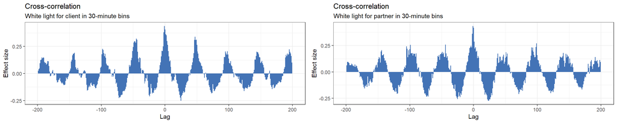

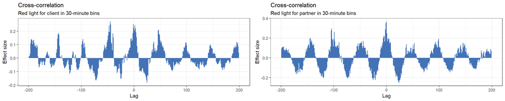

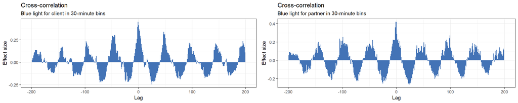

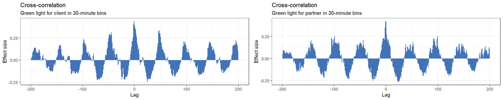

# Exploratory analysis

## On single dyad

A single dyad consisting of one client with chronic insomnia and their partner is used as example for analysis of the sleep status depending on time, light exposure and partner activity.

### Possible approaches/ hypotheses

When looking at 30-minute bins, sleep status over time most likely depends on diagnosis of insomnia. First, one may suspect that particularly in the insomnia patient, i.e. the client, light of specific wave lengths may enhance the probability of waking up. Second, insomnia patients may easily be woken up be movement by their bed-partners.

### Variables

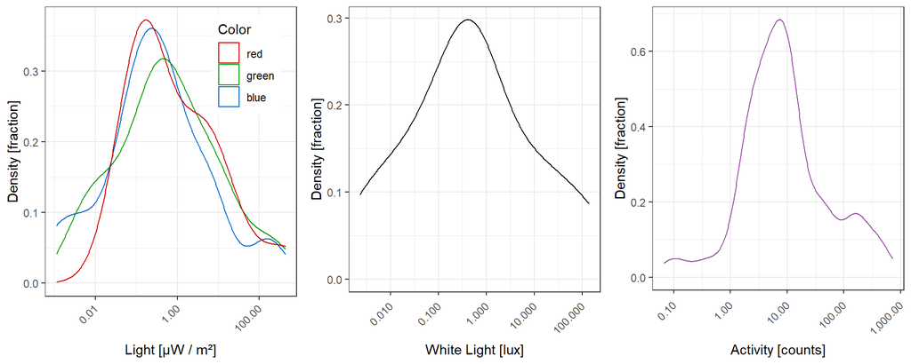

### Model setup and estimation

|  | *Dependent variable:* |
| --- | --- |
|  | sleep_wake |
| groupP | 0.670*** (0.438, 0.901) |
| night_time | 0.834*** (0.531, 1.138) |
| red_light | 0.981* (-0.095, 2.057) |
| green_light | -1.096** (-2.042, -0.149) |
| blue_light | 1.238*** (0.429, 2.047) |
| partner_activity | -0.001*** (-0.001, -0.0002) |
| groupP:night_time | -1.164*** (-1.561, -0.767) |
| groupP:red_light | -1.013* (-2.091, 0.065) |
| groupP:green_light | 1.114** (0.163, 2.065) |
| groupP:blue_light | -1.179*** (-2.025, -0.333) |
| groupP:partner_activity | 0.001*** (0.001, 0.002) |
| Constant | -0.344*** (-0.522, -0.166) |
| Observations | 237 |
| R<sup>2</sup> | 0.298 |
| Adjusted R<sup>2</sup> | 0.264 |
| Residual Std. Error | 0.132 (df = 225) |
| F Statistic | 8.698*** (df = 11; 225) |
| *Note:* | p<0.1; p<0.05; p<0.01 |

### Further considerations

However, further aspects that needs to be considered, in confirmatory hypothesis testing, e.g. correlation of subsequent bins, and that each day represents a repeated measurement of the same construct, sleep disturbance. One approach to account for the repeated measurement nature is to model data in a hierarchical fashion, e.g. using linear mixed models. Yet, because of the scarcity of above zero values in predictor variables, there are to few observations per day, which precludes to model clustering in days. Accordingly, estimation procedures yield singularity warnings.

Future analyses may incorporate the complete dataset in their analysis. During model setup, one should consider clustering of the data on different levels: observations are clustered within participants, and participants are clustered in dyads with their respective partners and within diagnosis group (client or partner). Using the full data set, the influence of light exposure and activity of the individual during wake hours on sleep periods and sleep disturbance could be investigated by using the aggregated data on actie and sleep periods provided by the summaries in the raw dataset. For the analysis, simplifying assumptions could be made, such as that sleep periods do not influence each other.